# Differentialy expression by LN group

Sara Gosline

7/12/2021

## Dive into lymph node status to investigate possible data separation

To build a model we want to break down patient samples into various classes based on their lymph node status.

Let’s first start by seeing how many patients have positive lymph nodes:

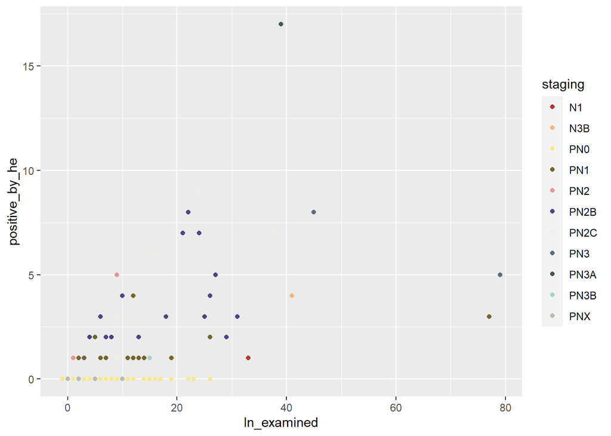

```r
       ggplot(clin.dat,aes(x=ln_examined,y=positive_by_he,col=staging))+geom_point()+
  scale_color_manual(values=pal)
```

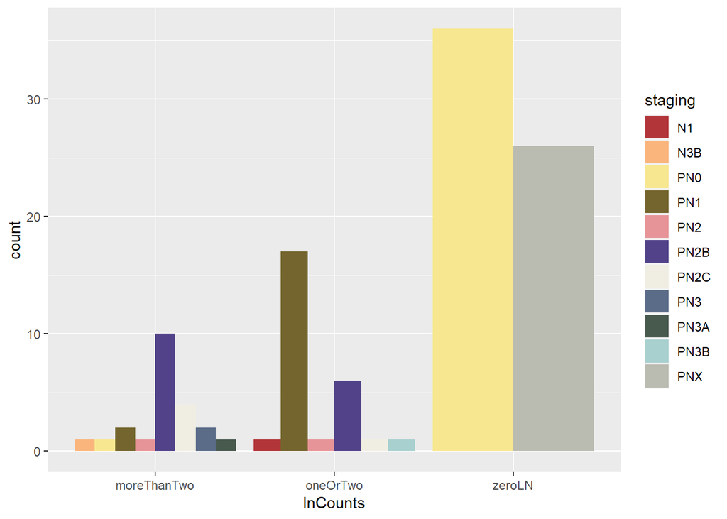

```r
ggplot(red.dat,aes(x=lnCounts,fill=staging))+geom_bar(position='dodge')+scale_fill_manual(values=pal)
```

## Group samples and get differential expression

Now we can compute proteins that are differentially expressed between LN classes.

```r
library(limma)

#create data matrix of samples and collect patients
protMat<-tumProts%>%
        pivot_wider(values_from='inferredTumAbund',names_from='patient')%>%
        tibble::column_to_rownames('Gene')

zpats=red.dat%>%subset(lnCounts=='zeroLN')%>%
        select(patient)%>%
        subset(patient%in%colnames(protMat))

opats=red.dat%>%subset(lnCounts=='oneOrTwo')%>%
        select(patient)%>%
        subset(patient%in%colnames(protMat))

mpats=red.dat%>%subset(lnCounts=='moreThanTwo')%>%
        select(patient)%>%
        subset(patient%in%colnames(protMat))

doLim<-function(dat,sampleIDs.group1,sampleIDs.group2){
  fac <- factor(rep(c(2,1), c(length(sampleIDs.group2), length(sampleIDs.group1))))
  design <- model.matrix(~fac)
  fit <- lmFit(dat[,c(sampleIDs.group2, sampleIDs.group1)], design)
  fit <- eBayes(fit)
 # print(topTable(fit, coef=2))
  res <- topTable(fit, coef=2, number=Inf, sort.by="none")
  res <- data.frame(featureID=rownames(res), res, stringsAsFactors = F)
  return(res)
}

oneVsZero=doLim(protMat,opats$patient,zpats$patient)
moreVsOne=doLim(protMat,mpats$patient,opats$patient)
moreVsZero=doLim(protMat,mpats$patient,zpats$patient)

allVsZero=doLim(protMat,c(opats$patient,mpats$patient),zpats$patient)

pthresh=0.01
combinedDF<-rbind(data.frame(condition='oneVsZero',subset(oneVsZero,P.Value<pthresh)),
                  data.frame(condition='moreVsOne',subset(moreVsOne,P.Value<pthresh)),
                  data.frame(condition='moreVsZero',subset(moreVsZero,P.Value<pthresh)))
##now

DT::datatable(combinedDF)
```

|  | condition | featureID | logFC | AveExpr | t | P.Value | adj.P.Val | B |
| --- | --- | --- | --- | --- | --- | --- | --- | --- |
| AASS | oneVsZero | AASS | 0.373575518761384 | 23.9819757995455 | 2.96597834107106 | 0.00387040661463693 | 0.913134780730723 | -2.48118990107249 |
| ABCC4 | oneVsZero | ABCC4 | -0.186594479471768 | 23.8121421505682 | -2.66940440762114 | 0.00902648488144051 | 0.913134780730723 | -2.95044441272689 |
| AHCYL2 | oneVsZero | AHCYL2 | 0.208613592950821 | 24.0339150696591 | 2.7817401260167 | 0.006596180184893 | 0.913134780730723 | -2.77720363517751 |
| ALG11 | oneVsZero | ALG11 | -0.17781626025501 | 23.2316444436364 | -2.72048206320841 | 0.00783517753824805 | 0.913134780730723 | -2.87236994537377 |
| ALOX15B | oneVsZero | ALOX15B | 0.481674818384942 | 22.6711700304545 | 2.75716088551382 | 0.00707005509451652 | 0.913134780730723 | -2.8155872195347 |
| ARMC9 | oneVsZero | ARMC9 | -0.250997578585308 | 23.1852508469318 | -2.83269880170676 | 0.00570495267590316 | 0.913134780730723 | -2.69678426718164 |
| BEND3 | oneVsZero | BEND3 | -0.233542826873104 | 20.7839080856818 | -2.88180004910228 | 0.00495202165196885 | 0.913134780730723 | -2.61823500851761 |
| BRK1 | oneVsZero | BRK1 | 0.127755635531266 | 26.2348467840909 | 2.64704271390387 | 0.00959801579844988 | 0.913134780730723 | -2.9842556334935 |
| C14orf119 | oneVsZero | C14orf119 | -0.281148453630845 | 22.1407528296591 | -2.92829386145764 | 0.00432438906366535 | 0.913134780730723 | -2.54291007269701 |
| C4orf54 | oneVsZero | C4orf54 | -0.505842701299334 | 22.8290017236364 | -2.69620114772796 | 0.00838239563741659 | 0.913134780730723 | -2.90963022229233 |

[output cut: 750 more lines]

## Biological pathway enrichment

Let’s compute the pathways (NCI Pathways) enriched upon proteins that are different between zero and 1/2 LN affected

```r
library(leapr)

data("ncipid")
data('krbpaths')
z.en <- leapR(geneset=ncipid,enrichment_method='enrichment_in_order',
              datamatrix=oneVsZero,primary_columns='logFC')%>%
        subset(BH_pvalue<0.05)

DT::datatable(select(z.en,-ingroupnames))
```

|  | ingroup_n | ingroup_mean | outgroup_n | outgroup_mean | score | oddsratio | pvalue | BH_pvalue | SignedBH_pvalue | background_n | background_mean | zscore |
| --- | --- | --- | --- | --- | --- | --- | --- | --- | --- | --- | --- | --- |
| avb3_integrin_pathway | 52 | 0.0395995772535139 | 9916 | 0.00235159963143893 |  | -0.241098302665467 | 0.00242360838771072 | 0.0203475738358573 | 0.0203475738358573 |  |  | 0.506922626182868 |
| bard1pathway | 16 | -0.0371992545442471 | 9916 | 0.00235159963143893 |  | 0.282233259378782 | 0.00506539388791971 | 0.0297783761895886 | -0.0297783761895886 |  |  | -0.941267147409465 |
| bcr_5pathway | 53 | 0.0544690344028588 | 9916 | 0.00235159963143893 |  | -0.352599572256007 | 1.48094128138432e-06 | 9.57675361961859e-05 | 9.57675361961859e-05 |  |  | 0.753328485647714 |
| cd8tcrpathway | 41 | 0.0616435053011382 | 9916 | 0.00235159963143893 |  | -0.39569456606224 | 2.07083838377198e-05 | 0.000573918066359662 | 0.000573918066359662 |  |  | 0.927043990612628 |
| cdc42_pathway | 58 | 0.0336099832031066 | 9916 | 0.00235159963143893 |  | -0.258255553546341 | 0.00019313998336068 | 0.00288224282861322 | 0.00288224282861322 |  |  | 0.32505251528904 |
| cxcr3pathway | 31 | 0.0576623238378669 | 9916 | 0.00235159963143893 |  | -0.368326198128798 | 0.000120249117937621 | 0.0019440274066582 | 0.0019440274066582 |  |  | 0.676051319674137 |
| cxcr4_pathway | 80 | 0.0466480341262897 | 9916 | 0.00235159963143893 |  | -0.28378126260589 | 8.43177408893503e-06 | 0.000327152834650679 | 0.000327152834650679 |  |  | 0.529517177450585 |
| ecadherin_stabilization_pathway | 29 | 0.0452214224307513 | 9916 | 0.00235159963143893 |  | -0.303299439429136 | 0.00361973782149994 | 0.0250796120489638 | 0.0250796120489638 |  |  | 0.319570180760621 |
| endothelinpathway | 39 | 0.0429711872268143 | 9916 | 0.00235159963143893 |  | -0.263867771330458 | 0.00152862743650239 | 0.0141216058419745 | 0.0141216058419745 |  |  | 0.513428886115459 |
| ephbfwdpathway | 32 | 0.0330198848890021 | 9916 | 0.00235159963143893 |  | -0.209900665590964 | 0.00677050860486628 | 0.0375279619812588 | 0.0375279619812588 |  |  | 0.390862375108598 |

[output cut: 26 more lines]

Now let’s look at pathways that go from 1/2 LN to more than 1/2

```r
m.en <-leapR(geneset=ncipid,enrichment_method='enrichment_in_order',
             datamatrix=moreVsOne,primary_columns='logFC')%>%
        subset(BH_pvalue<0.05)

DT::datatable(select(m.en,-ingroupnames))
```

|  | ingroup_n | ingroup_mean | outgroup_n | outgroup_mean | score | oddsratio | pvalue | BH_pvalue | SignedBH_pvalue | background_n | background_mean | zscore |
| --- | --- | --- | --- | --- | --- | --- | --- | --- | --- | --- | --- | --- |
| atr_pathway | 30 | -0.0923601130213241 | 9916 | 0.00250038751207099 |  | 0.421177894312223 | 0.000498192206647707 | 0.0322164293632184 | -0.0322164293632184 |  |  | -0.791301049045025 |
| aurora_b_pathway | 26 | -0.141949982982388 | 9916 | 0.00250038751207099 |  | 0.577861730846805 | 1.13739797034107e-05 | 0.00220655206246168 | -0.00220655206246168 |  |  | -1.11123544247125 |
| integrin2_pathway | 22 | 0.0878514570423938 | 9916 | 0.00250038751207099 |  | -0.443204737980857 | 0.000140744567953432 | 0.013652223091483 | 0.013652223091483 |  |  | 0.570672106371902 |

## Plot changing proteins

Now let’s see if we can plot the patient samples by the proteins involved

```r
zprots=subset(oneVsZero,P.Value<pthresh)%>%select(featureID)
mprots=subset(moreVsOne,P.Value<pthresh)%>%select(featureID)

redProts <- fullProts%>%
  subset(Gene%in%c(zprots$featureID,mprots$featureID))

##let's first do a PCA plotted with positive lns
tumAbund <- pcaFromDf(redProts,'inferredTumAbund')%>%
  left_join(clin.dat,by='patient')
```

[output not shown]

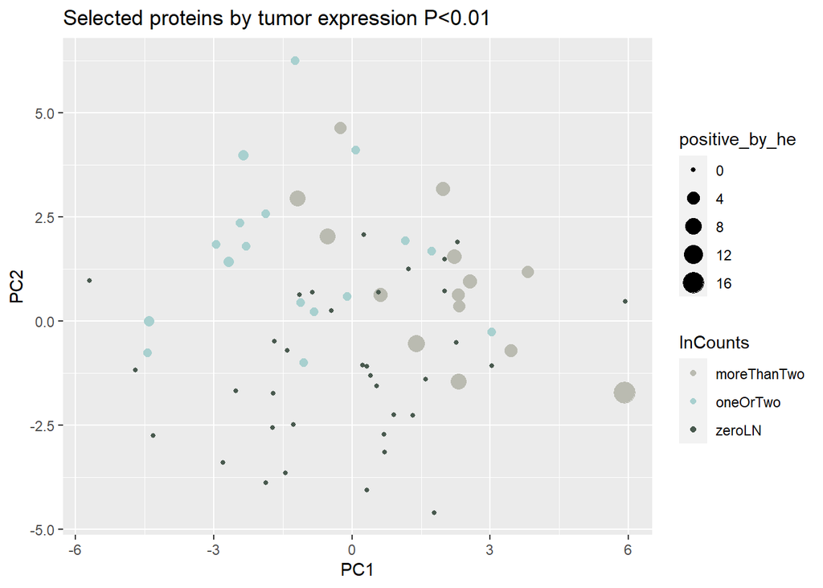

```r
##all proteins
tumAbund%>%left_join(select(red.dat,c(patient,lnCounts)),by='patient')%>%
ggplot()+
  geom_point(aes(x=PC1,y=PC2,col=lnCounts,size=positive_by_he))+
  ggtitle(paste0('Selected proteins by tumor expression P<',pthresh))+scale_color_manual(values=rev(pal))
```